# BCVs - Analysis financed emissions of mortgages

Annika Schmidt

2024-10-22

# LOAD PACKAGES

```r
# LOAD PACKAGES ############################################
install.packages("pacman")
install.packages("openxlsx")
install.packages("knitr")
```

```r
pacman::p_load(pacman, dplyr, GGally, ggplot2, ggthemes,
               ggvis, httr, lubridate, plotly, rio, rmarkdown, shiny,
               stringr, tidyr)
library(datasets)
library(openxlsx)
library(ggplot2)
library(dplyr)
library(knitr)
```

# IMPORT FILE

```r
# Excel XLSX
INTERACTIVE <- TRUE
if (INTERACTIVE) {
  file_in <- file.choose() # Use File Explorer
} else {
  file_in <- excel_filepath
}
wb <- openxlsx2::wb_load(file_in)

# Read the excel file
data <- openxlsx2::wb_to_df(wb, sheet = "byBuilding", start_row = 5, col_names = TRUE)
data_subset <- data[1:31746, ]
# Check the new dimensions
cat("Number of rows in the subset:", nrow(data_subset), "\n")
```

```
## Number of rows in the subset: 31746
```

# PRE-ANALYSIS

## ERROR COMMENTS

```r
# Group by ErrorComments and count occurrences
error_summary <- data_subset %>%
  filter(!is.na(error_comments)) %>%
  group_by(error_comments) %>%
  summarise(Count = n()) %>%
  arrange(desc(Count))

# View the summary
kable(error_summary, caption = "Summary of Error Comments")
```

Summary of Error Comments

| error_comments | Count |
| --- | --- |
| Multiple EGIDs found. | 4470 |
| No EGID found. | 3701 |
| The Building cannot be processed because the ground area or the number of floors is unknown. | 450 |
| Argument hat Länge 0 | 179 |
| No Building class (GKLAS) found on RegBl database. | 177 |
| Building is demolished. Stop the process. | 84 |
| No building found with the provided EGID. | 9 |
| Failed to retrieve data from the API. Status code: 400 |  |
| Turn off the `geoadmin_api_search` parameter to skip this step. | 5 |

## cHECK FOR OUTLIERS

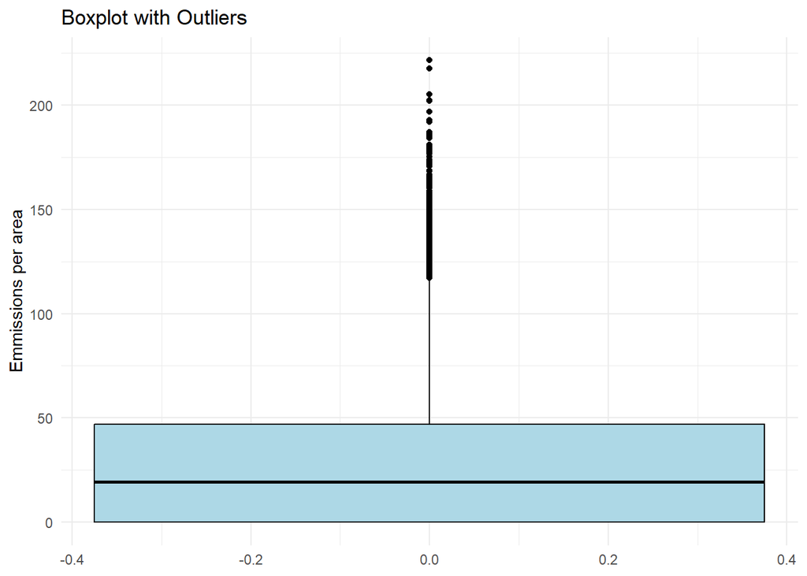

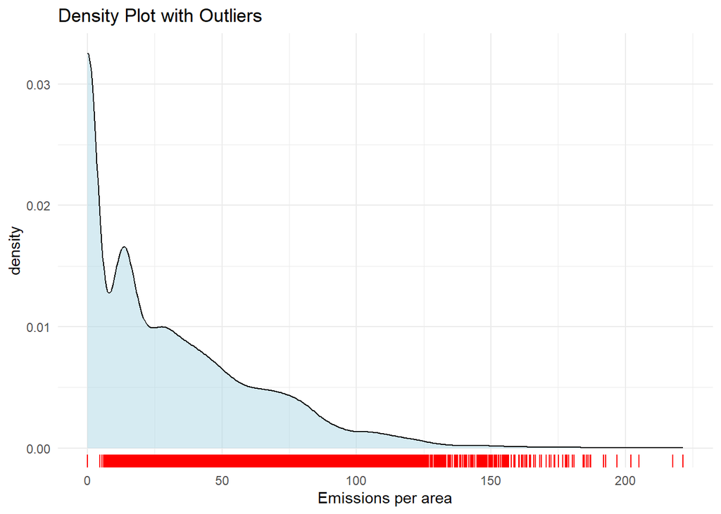

### FILTER OUTLIERS

```r
# Mutate observations where 'emissions_per_area' is greater 150
data_subset_reduced <- data %>%
  mutate(emissions_per_area = ifelse(emissions_per_area > 150, NA, emissions_per_area))
```

## CREATE VARIABLES

```r
# energy intensity in kWh per m2
conversion_factor <- 0.277777778
data_subset$energy_intensity <- data_subset$heat_energy * conversion_factor

# Create a subset where mortgage_value is not NA
data_subset_non_na_mortgage <- data_subset %>%
  filter(!is.na(mortgage_emissions))

# Total energetic surface of the assets (m2)
total_asset_energetic_area <- sum(data_subset$asset_energetic_area, na.rm = TRUE)

# total asset value (CHF)
total_asset_value <- sum(data_subset$asset_value, na.rm = TRUE)

# total mortgage value (CHF)
total_mortgage_value <- sum(data_subset$mortgage_value, na.rm = TRUE)
total_mortgage_value_subset <- sum(data_subset_non_na_mortgage$mortgage_value, na.rm = TRUE)

# total asset emissions (absolute, in kg CO2)
total_asset_emissions <- sum(data_subset$asset_emissions, na.rm = TRUE)
# total financed emissions (absolute, in kg CO2)
# variable already multiplied by bank share
total_financed_emissions <- sum(data_subset$mortgage_emissions, na.rm =TRUE)

# Mean emission intensity (t CO2eq / Mio. CHF invested)
mean_emission_intensity_per_investment <- (sum(data_subset$mortgage_emissions, na.rm = TRUE)/1000)/(total_mortgage_value_subset/1000000)

# Mean emission intensity (kg CO2/ m2)
mean_emission_intensity_per_m2 <- mean(data_subset$emissions_per_area, na.rm = TRUE)

# Mean energy intensity (kWh/ m2)
mean_energy_intensity_per_m2 <- mean(data_subset$energy_intensity, na.rm = TRUE)

# mean bank share of mortgage on total assets
mean_bank_share <- total_mortgage_value / total_asset_value
```

```r
options(scipen = 999)
# Create a data frame to summarize all the variables
summary_variables <- data.frame(
  Metric = c("Total Asset Energetic Area (m2)",
             "Total Asset Value (CHF)",
             "Total Mortgage Value (CHF)",
             "Total Asset Emissions (kg CO2)",
             "Total Financed Emissions (kg CO2)",
             "Mean Emission Intensity per Mio CHF (t CO2eq/ Mio. CHF invested)",
             "Mean Emission Intensity per m2 (kg CO2/m2)",
             "Mean energy intensity (kWh/ m2)",
             "Mean Bank Share of Mortgage on Total Assets"),
  Value = c(total_asset_energetic_area,
            total_asset_value,
            total_mortgage_value,
            total_asset_emissions,
            total_financed_emissions,
            mean_emission_intensity_per_investment,
            mean_emission_intensity_per_m2,
            mean_energy_intensity_per_m2,
            mean_bank_share)
)
# Print the data frame
kable(summary_variables)
```

| Metric | Value |
| --- | --- |
| Total Asset Energetic Area (m2) | 8864875.3054166 |
| Total Asset Value (CHF) | 24001048637.0000000 |
| Total Mortgage Value (CHF) | 12565575564.0000000 |
| Total Asset Emissions (kg CO2) | 241888112.9825729 |
| Total Financed Emissions (kg CO2) | 116059061.1151357 |
| Mean Emission Intensity per Mio CHF (t CO2eq/ Mio. CHF invested) | 12.7543450 |
| Mean Emission Intensity per m2 (kg CO2/m2) | 29.3156075 |
| Mean energy intensity (kWh/ m2) | 164.3809794 |
| Mean Bank Share of Mortgage on Total Assets | 0.5235428 |

# ANALYSIS

## USAGE TYPES

```r
# Count the number of occurrences for each distinct usage type
usage_type_counts <- data_subset %>%
  group_by(`Usage de l'immeuble`) %>%
  summarise(count = n())

# Output the counts for each usage type
usage_type_counts
```

```
## # A tibble: 22 × 2
##    `Usage de l'immeuble`                             count
##    <chr>                                             <int>
##  1 Aide fédérale (OFL)                                  88
##  2 Destinée à la vente (promotion) - rés. primaire      10
##  3 Destinée à la vente (promotion) - rés. secondaire     2
##  4 Droit de superficie                                  59
##  5 Hôtels / restaurant (location)                       53
##  6 Hôtels / restaurant (usage propre)                  126
##  7 Location                                           2082
##  8 Loi droit foncier rural (LDFR)                      199
##  9 PPE Bureau / Magasin (location)                      72
## 10 PPE Bureau / Magasin (usage propre)                  37
## # ℹ 12 more rows
```

## BUILDING TYPES

```r
# Count the number of occurrences for each distinct building type
building_type_counts <- data_subset %>%
  group_by(`Type d'immeuble`) %>%
  summarise(count = n())

# Output the counts for each usage type
building_type_counts
```

```
## # A tibble: 10 × 2
##    `Type d'immeuble`    count
##    <chr>                <int>
##  1 Agriculture             98
##  2 Autres objets           40
##  3 Bureau / Magasin         5
##  4 Commerce / industrie   649
##  5 Habitat / commerce     298
##  6 Immeuble collectif     634
##  7 Maison individuelle  12602
##  8 Propriété par étage  16930
##  9 Terrain                485
## 10 <NA>                     5
```

```r
data_subset <- data_subset %>%
  mutate(mortgage_type = if_else(`Habitation` == "1", "Residential", "Commercial"))
```

## ANALYSIS BY

```r
type_summary_mortgage <- data_subset %>%
  group_by(mortgage_type) %>%
  summarise(
    mean_energy = mean(energy_intensity, na.rm = TRUE),
    mean_emissions = mean(emissions_per_area, na.rm = TRUE),
    mean_emission_intensity_per_investment = (sum(mortgage_emissions, na.rm = TRUE)/1000)/((sum(mortgage_value[!is.na(mortgage_emissions)], na.rm = TRUE)/1000000)),
    sum_financed_emissions = sum(asset_emissions, na.rm = TRUE),
    sum_asset_energetic_area = sum(asset_energetic_area, na.rm = TRUE),
    share_mortgage_value = (sum(mortgage_value, na.rm = TRUE)/ total_mortgage_value),
    count = n()
  )
print(type_summary_mortgage, caption = "Emission Summary by Mortgage Type")
```

```
## # A tibble: 3 × 8
##   mortgage_type mean_energy mean_emissions mean_emission_intensity_per_investm…¹
##   <chr>               <dbl>          <dbl>                                 <dbl>
## 1 Commercial           159.           31.2                                  25.1
## 2 Residential          165.           29.2                                  11.7
## 3 <NA>                 NaN           NaN                                   NaN
## # ℹ abbreviated name: ¹mean_emission_intensity_per_investment
## # ℹ 4 more variables: sum_financed_emissions <dbl>,
## #   sum_asset_energetic_area <dbl>, share_mortgage_value <dbl>, count <int>
```

The investment amounts (the denominator in your intensity calculation) could differ significantly between the two mortgage types. For example, residential mortgages are often smaller, but more numerous, while commercial mortgages may involve fewer but much larger loans. If the total invested in residential mortgages is much higher, but the emissions are relatively lower, this would naturally lead to a lower emission intensity per investment for residential properties.

```r
# Filter data for Commercial mortgages

commercial_data <- data_subset %>%
  filter(mortgage_type == "Commercial") %>%
  mutate(
    emission_intensity_per_investment = (mortgage_emissions / 1000) / (mortgage_value[!is.na(mortgage_emissions)] / 1000000)
  )
```

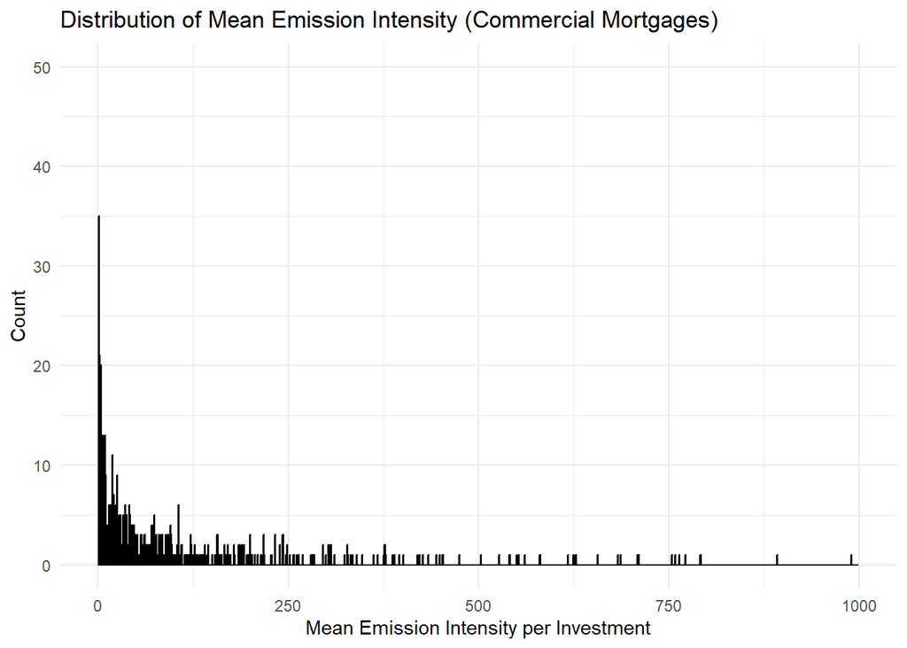

```r
# Plot distribution
ggplot(commercial_data, aes(x =  emission_intensity_per_investment)) +
  geom_histogram(binwidth = 1, fill = "blue", color = "black", alpha = 0.7) +
  labs(title = "Distribution of Mean Emission Intensity (Commercial Mortgages)",
       x = "Mean Emission Intensity per Investment",
       y = "Count") +
  xlim(0,1000)+
  ylim(0,50)+
  theme_minimal()
```

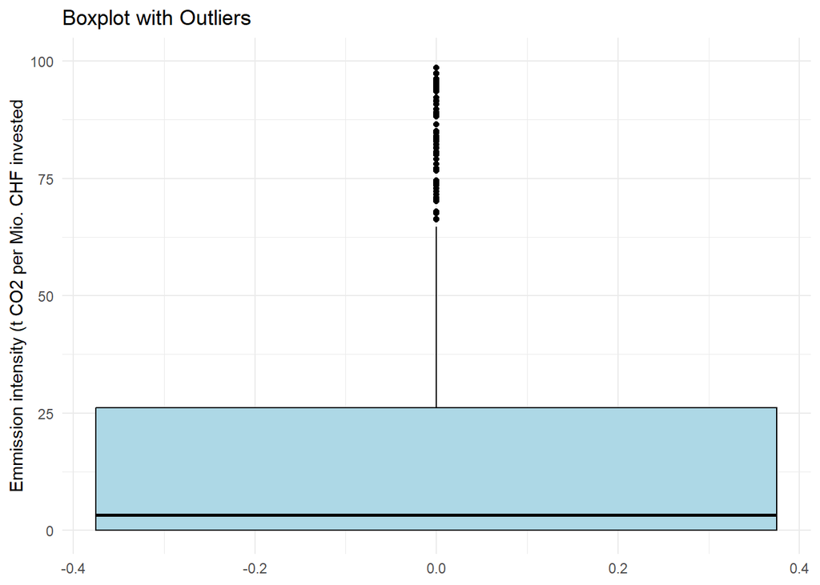

```r
ggplot(commercial_data, aes(y = emission_intensity_per_investment)) +
  geom_boxplot(fill = "lightblue", color = "black") +
  labs(title = "Boxplot with Outliers", y = "Emmission intensity (t CO2 per Mio. CHF invested") +
  theme_minimal()+
  ylim(0,100)
```

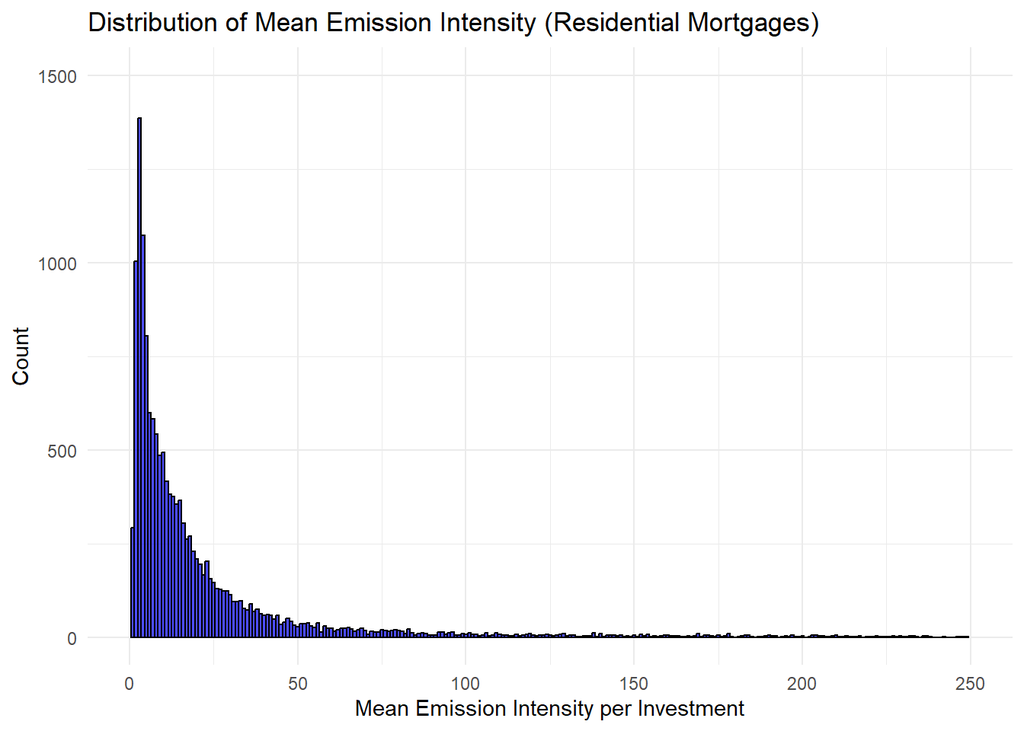

```r
# Filter data for Commercial mortgages

residential_data <- data_subset %>%
  filter(mortgage_type == "Residential") %>%
  mutate(
    emission_intensity_per_investment = (mortgage_emissions / 1000) / (mortgage_value / 1000000)
  )

# Plot distribution
ggplot(residential_data, aes(x =  emission_intensity_per_investment)) +
  geom_histogram(binwidth = 1, fill = "blue", color = "black", alpha = 0.7) +
  labs(title = "Distribution of Mean Emission Intensity (Residential Mortgages)",
       x = "Mean Emission Intensity per Investment",
       y = "Count") +
  xlim(0,250)+
  ylim(0,1500)+
  theme_minimal()
```

### 2) BUILDING TYPE

```r
type_summary_building_type <- data_subset %>%
  group_by(`Type d'immeuble`) %>%
  summarise(
    sum(asset_value, na.rm = TRUE),
    sum(mortgage_value, na.rm  = TRUE),
    mean_energy = mean(energy_intensity, na.rm = TRUE),
    mean_emissions = mean(emissions_per_area, na.rm = TRUE),
    mean_emission_intensity_per_investment = sum(mortgage_emissions, na.rm = TRUE)/1000/(sum(mortgage_value[!is.na(mortgage_emissions)], na.rm = TRUE)/1000000),
    sum_asset_emissions = sum(asset_emissions, na.rm = TRUE),
    sum_asset_energetic_area = sum(asset_energetic_area, na.rm = TRUE),
    share_mortgage_value = (sum(mortgage_value, na.rm = TRUE)/ total_mortgage_value),
    count = n()
  )
print(type_summary_building_type, caption = "Emission Summary by Building Type")
```

```
## # A tibble: 10 × 10
##    `Type d'immeuble`   sum(asset_value, na.…¹ sum(mortgage_value, …² mean_energy
##    <chr>                                <dbl>                  <dbl>       <dbl>
##  1 Agriculture                       30342473               16348881        194.
##  2 Autres objets                    707059034               68822806        206.
##  3 Bureau / Magasin                 598108000               46473250        158.
##  4 Commerce / industr…             2035761253              833695520        162.
##  5 Habitat / commerce               431775624              205553175        204.
##  6 Immeuble collectif               923791780              495380702        226.
##  7 Maison individuelle             9905712480             5568329881        191.
##  8 Propriété par étage             9128747409             5244528442        136.
##  9 Terrain                          239750584               86442907        216.
## 10 <NA>                                     0                      0        NaN
## # ℹ abbreviated names: ¹`sum(asset_value, na.rm = TRUE)`,
## #   ²`sum(mortgage_value, na.rm = TRUE)`
## # ℹ 6 more variables: mean_emissions <dbl>,
## #   mean_emission_intensity_per_investment <dbl>, sum_asset_emissions <dbl>,
## #   sum_asset_energetic_area <dbl>, share_mortgage_value <dbl>, count <int>
```

### 2) USAGE TYPE

```r
type_summary_usage_type <- data_subset %>%
  group_by(`Usage de l'immeuble`) %>%
  summarise(
    mean_energy = mean(energy_intensity, na.rm = TRUE),
    mean_emissions = mean(emissions_per_area, na.rm = TRUE),
    mean_emission_intensity_per_investment = sum(mortgage_emissions, na.rm = TRUE)/1000/(sum(mortgage_value[!is.na(mortgage_emissions)], na.rm = TRUE)/1000000),
    sum_financed_emissions = sum(asset_emissions, na.rm = TRUE),
    sum_asset_energetic_area = sum(asset_energetic_area, na.rm = TRUE),
    share_mortgage_value = (sum(mortgage_value, na.rm = TRUE)/ total_mortgage_value),
    count = n()
  )
print(type_summary_usage_type, caption = "Emission Summary by Usage Type")
```

```
## # A tibble: 22 × 8
##    `Usage de l'immeuble`       mean_energy mean_emissions mean_emission_intens…¹
##    <chr>                             <dbl>          <dbl>                  <dbl>
##  1 Aide fédérale (OFL)               146.           30.7                 28.7
##  2 Destinée à la vente (promo…        46.1           8.50                 1.49
##  3 Destinée à la vente (promo…        33.3          10.0                  0.0706
##  4 Droit de superficie                82.3          18.1                 16.2
##  5 Hôtels / restaurant (locat…       183.           43.3                 20.4
##  6 Hôtels / restaurant (usage…       206.           51.2                 30.1
##  7 Location                          154.           30.2                 18.1
##  8 Loi droit foncier rural (L…       195.           13.4                 20.5
##  9 PPE Bureau / Magasin (loca…       114.           18.2                 27.9
## 10 PPE Bureau / Magasin (usag…       138.           25.7                 54.3
## # ℹ 12 more rows
## # ℹ abbreviated name: ¹mean_emission_intensity_per_investment
## # ℹ 4 more variables: sum_financed_emissions <dbl>,
## #   sum_asset_energetic_area <dbl>, share_mortgage_value <dbl>, count <int>
```

```r
gklas_mapping <- data.frame(
  GKLAS = c(1110, 1121, 1122, 1130, 1211, 1212, 1220, 1230, 1231, 1241),
  GKLAS_def = c('Maisons à un logement', 'Maisons à deux logements', 'Immeubles à trois logements et plus', 'Habitat communautaire', 'Hôtels', 'Autres bâtiments dhébergement de tourisme', 'Immeubles de bureaux', 'Bâtiments commerciaux', 'Restaurants et bars dans des bâtiments sans usage résidentiel', 'Gares, aérogares, centraux téléphoniques')  # Replace with your specific numbers
)

# Join the mapping table with the original data frame
data_subset <- data_subset %>%
  left_join(gklas_mapping, by = "GKLAS")
```

### 3) GKLAS

GKLAS = Classe de bâtiment selon EUROSTAT (voir RegBL_Catalogue, page 57/58)

```r
type_summary_GKLAS <- data_subset %>%
  group_by(GKLAS_def) %>%
  summarise(
    mean_energy = mean(energy_intensity, na.rm = TRUE),
    mean_emissions = mean(emissions_per_area, na.rm = TRUE),
    mean_emission_intensity_per_investment = sum(mortgage_emissions, na.rm = TRUE)/1000/(sum(mortgage_value[!is.na(mortgage_emissions)], na.rm = TRUE)/1000000),
    sum_financed_emissions = sum(asset_emissions, na.rm = TRUE),
    sum_asset_energetic_area = sum(asset_energetic_area, na.rm = TRUE),
    share_mortgage_value = (sum(mortgage_value, na.rm = TRUE)/ total_mortgage_value),
    count = n()
  )
print(type_summary_GKLAS, caption = "Emission Summary by GKLAS")
```

```
## # A tibble: 11 × 8
##    GKLAS_def                   mean_energy mean_emissions mean_emission_intens…¹
##    <chr>                             <dbl>          <dbl>                  <dbl>
##  1 Autres bâtiments dhébergem…        215.           38.3                  34.6
##  2 Bâtiments commerciaux              148.           28.9                  18.0
##  3 Gares, aérogares, centraux…        182.            0                     0
##  4 Habitat communautaire              143.           32.1                   9.22
##  5 Hôtels                             187.           49.1                  33.6
##  6 Immeubles de bureaux               167.           25.3                   9.22
##  7 Immeubles à trois logement…        128.           27.6                  17.6
##  8 Maisons à deux logements           229.           38.5                  14.4
##  9 Maisons à un logement              187.           28.7                   7.87
## 10 Restaurants et bars dans d…        224.           62.6                 218.
## 11 <NA>                               140.           19.4                  16.2
## # ℹ abbreviated name: ¹mean_emission_intensity_per_investment
## # ℹ 4 more variables: sum_financed_emissions <dbl>,
## #   sum_asset_energetic_area <dbl>, share_mortgage_value <dbl>, count <int>
```

### 4) ENERGY CARRIER

```r
type_summary_energy_carrier <- data_subset %>%
  group_by(sia_energy_carrier) %>%
  summarise(
    mean_energy = mean(energy_intensity, na.rm = TRUE),
    mean_emissions = mean(emissions_per_area, na.rm = TRUE),
    mean_emission_intensity_per_investment = sum(mortgage_emissions, na.rm = TRUE)/1000/(sum(mortgage_value[!is.na(mortgage_emissions)], na.rm = TRUE)/1000000),
    sum_financed_emissions = sum(asset_emissions, na.rm = TRUE),
    sum_asset_energetic_area = sum(asset_energetic_area, na.rm = TRUE),
    share_mortgage_value = (sum(mortgage_value, na.rm = TRUE)/ total_mortgage_value),
    count = n()
  )
print(type_summary_energy_carrier, caption = "Emission Summary by Energy Carrier")
```

```
## # A tibble: 4 × 8
##   sia_energy_carrier mean_energy mean_emissions mean_emission_intensity_per_in…¹
##   <chr>                    <dbl>          <dbl>                            <dbl>
## 1 gasHeating                139.           30.3                             15.7
## 2 oilHeating                163.           48.2                             19.5
## 3 other                     185.            0                                0
## 4 <NA>                      NaN           NaN                              NaN
## # ℹ abbreviated name: ¹mean_emission_intensity_per_investment
## # ℹ 4 more variables: sum_financed_emissions <dbl>,
## #   sum_asset_energetic_area <dbl>, share_mortgage_value <dbl>, count <int>
```

Now, export all summaries to Excel

```r
wb2 <- createWorkbook()
# List of data frames (tables) to export
tables_list <- list(
  "Mortgage Type Summary" = type_summary_mortgage,
  "Building Type Summary" = type_summary_building_type,
  "Usage Type Summary" = type_summary_usage_type,
  "GKLAS Summary" = type_summary_GKLAS,
  "Energy Carrier Summary" = type_summary_energy_carrier
)

# Loop over the list of tables and export each as a sheet
for (sheet_name in names(tables_list)) {
  addWorksheet(wb2, sheet_name) # Create a sheet with the table name
  writeData(wb2, sheet = sheet_name, tables_list[[sheet_name]]) # Write the table to the corresponding sheet
}

# Save the workbook to an Excel file
saveWorkbook(wb2, "Emission_Summary_Tables_BCVs.xlsx", overwrite = TRUE)
```

# COVERAGES

## 1) Relative to number of mortgages

Comparing the number of non-missing values for each variable to the total number of rows (one row = one mortgage)

```r
#


# Addresses available = proportion of addresses for which we have valid data.
total_rows <- nrow(data_subset)
print(total_rows)
```

```
## [1] 31746
```

```r
# Coverage ratio for EGID (non-missing EGID)
coverage_EGID <- sum(!is.na(data_subset$EGID)) / total_rows
print(coverage_EGID)
```

```
## [1] 0.7424557
```

```r
# Coverage ratio for emisisons_per_area
coverage_mortgage_emissions <- sum(!is.na(data_subset$mortgage_emissions)) / total_rows
print(coverage_mortgage_emissions)
```

```
## [1] 0.7141372
```

## 2) Coverage ratio for financed emissions relative to investments (%)

```r
# where do I have data for mortage emissions, * mortgage_value / total_mortgage_value
data_subset <- data_subset %>%
  mutate(
    emissions_proportion = ifelse(is.na(mortgage_emissions),
                                  mortgage_value,
                                  NA)
  )
coverage_financed_emissions <- sum(data_subset$emissions_proportion, na.rm = TRUE) / total_mortgage_value
print(1-coverage_financed_emissions)
```

```
## [1] 0.7241666
```

Whereas the code can get results for 71% of the rows, we have results for 72% of total mortgage value.

## 3) Coverage ratio related to area

Sum of energy relevant area when financed emissions is not NA / Total energy relevant area

```r
coverage_ratio_area <- data_subset %>%
  summarise(
    sum_area_condition = sum(asset_energetic_area[!is.na(mortgage_emissions)], na.rm = TRUE),
    sum_area = sum(asset_energetic_area, na.rm = TRUE)
  ) %>%
  mutate(ratio = sum_area_condition / sum_area)

print(coverage_ratio_area)
```

```
##   sum_area_condition sum_area     ratio
## 1            8560979  8864875 0.9657191
```

## 4) Coverage of conservative assumption of Oil

Count where Variable GENH1 equal to 7598 (Indéterminé) or 7599 (Autre). For those the assumption of Oil was used. Thus, we used the emission factor of 0.0737.

```r
#
count_assumption <- data_subset %>%
  filter(GENH1 %in% c(7598, 7599)) %>%
  summarise(
    count = n()/total_rows,
    total_emissions_share = sum(mortgage_emissions, na.rm = TRUE)/ total_financed_emissions
  )

# Print the result
print(count_assumption)
```

```
##       count total_emissions_share
## 1 0.1354186             0.1459442
```

For 13.5% of total mortgages (31’746) we have used the assumption of oil heating as we did not have information on the energy carrier. The assumption of oil heating, when no information was available, makes up 14.6 % of all absolute emissions (t CO2 116’059) of the BCVs.

# PLOTS

According to years built

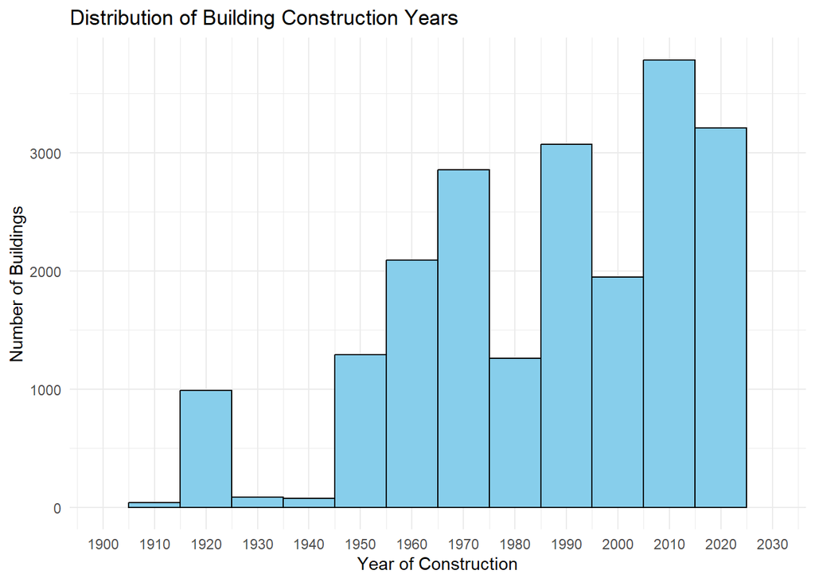

```r
ggplot(data = data_subset, aes(x = sia_year)) +
  geom_histogram(binwidth = 10, fill = "skyblue", color = "black") +
  labs(title = "Distribution of Building Construction Years",
       x = "Year of Construction",
       y = "Number of Buildings") +
  scale_x_continuous(breaks = seq(1900, 2030, by = 10), limits = c(1900,2030)) +
  scale_y_continuous(breaks = seq(0, 35000, by = 1000)) +
  theme_minimal() # Adjust breaks as needed
```

Distribution of emissions per area (kg CO2/m2)

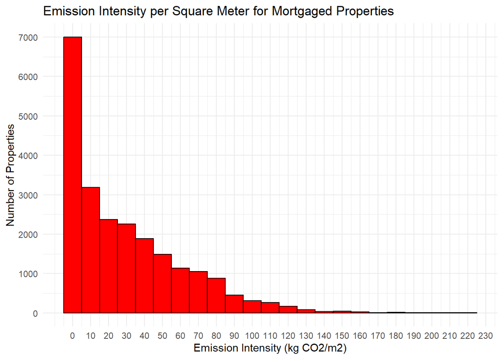

```r
ggplot(data = data_subset, aes(x = emissions_per_area)) +
  geom_histogram(binwidth = 10, fill = "red", color = "black") +
  labs(title = "Emission Intensity per Square Meter for Mortgaged Properties",
       x = "Emission Intensity (kg CO2/m2)",
       y = "Number of Properties") +
  scale_x_continuous(breaks = seq(0, 400, by = 10)) +
  scale_y_continuous(breaks = seq(0, 35000, by = 1000)) + # Adjust breaks as needed
  theme_minimal()
```

Share of different energy carriers

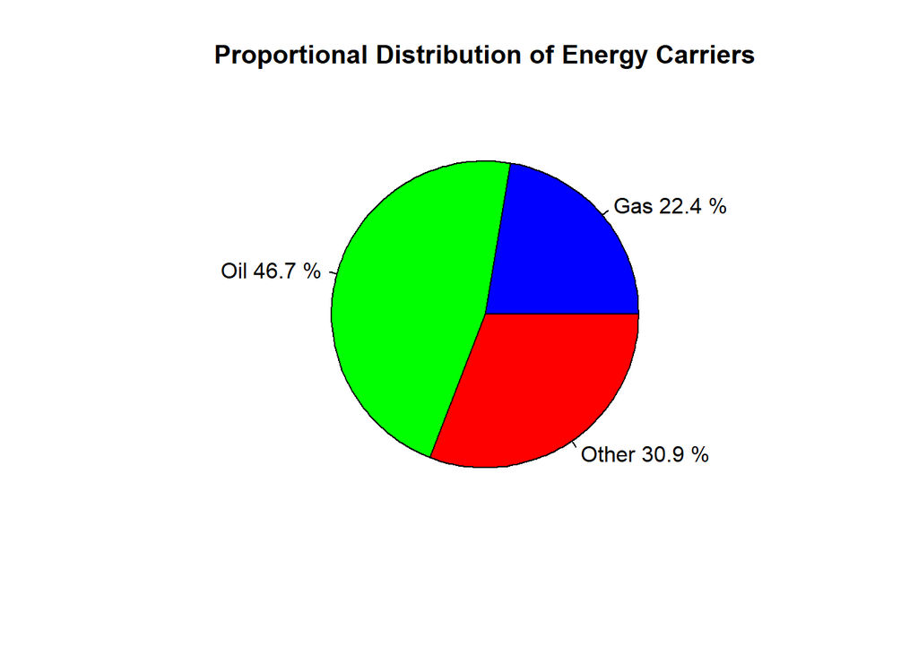

```r
data_subset$energy_carrier[data_subset$sia_energy_carrier == "4"] <- NA ##
energy_carrier_counts <- table(data_subset$sia_energy_carrier)
custom_names <- c("Gas","Oil","Other")

pie(energy_carrier_counts,
    labels = paste(custom_names, round(prop.table(energy_carrier_counts) * 100, 1), "%"),
    col = c("blue", "green", "red"),
    main = "Proportional Distribution of Energy Carriers")
```